# M8752 Pokročilé regresní modely I

- Show All Code
- Hide All Code
- View Source

Úloha ku skúške

Autor

Michaela Marčeková

Publikované

June 10, 2025

```r
library(tidyr)
library(ggplot2)
library(dplyr)
library(patchwork)
library(gtsummary)
library(data.table)
library(sandwich)
```

Dáta popisujú výsledky laboratórneho experimentu nejakého biologického rastového procesu. Experiment prebiehal počas niekoľkých dní (premenná `day`). V každý deň bola zaznamenaná dosiahnutá veľkosť (premenná `size`). Experiment prebiehal za rovnakých podmienok súčasne a nezávisle na viacerých experimentálnych jednotkách, ktoré sú označené premennou `id`. Cieľom je modelovať závislosť veľkosti od času.

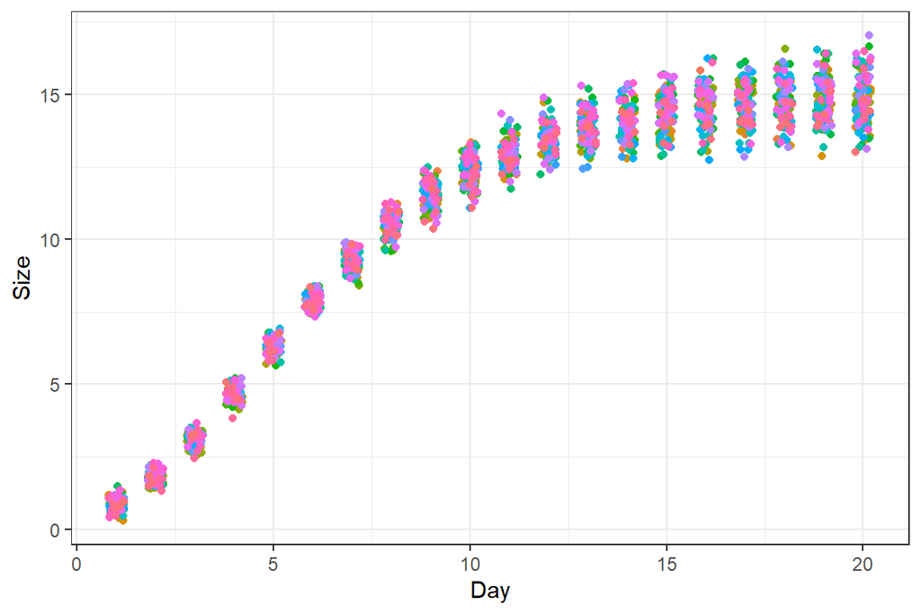

```r
growth = fread("growth.csv")
growth[,id:=as.factor(id)]
setkey(growth,id,day)
library(ggplot2); theme_set(theme_bw())
ggplot(growth,aes(x=jitter(day),y=size,col=id)) +
  geom_point() +
  labs(x="Day",y="Size") + theme(legend.position="none")
```

Z grafu je vidieť, že rast sa v priebehu času spomaľuje a veľkosť sa blíži k nejakej limitnej hodnote. Preto bude vhodné uvažovať niektorý nelineárny rastový model. Pre tieto údaje je vhodný Gompertzov model.

```r
dat <- data.frame(growth)
```

# Popis dát

| **Premenná** | **Typ** | **Popis** |
| --- | --- | --- |
| `id` | ID (factor) | identifikátor jednotky |
| `day` | numerická (int) | čas v dňoch |
| `size` | numerická (num) | pozorovaná veľkosť |

```
Chýbajuce hodnoty
```

```r
colSums(is.na(dat))
```

```
  id  day size
   0    0    0
```

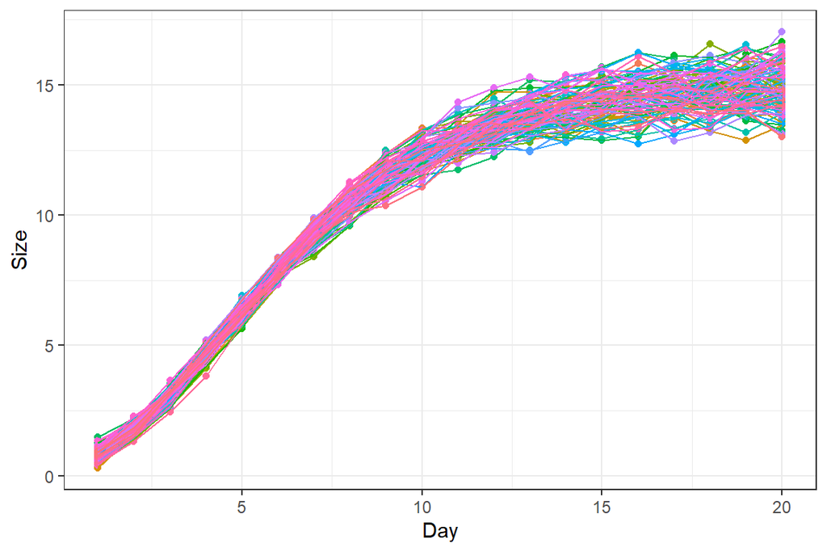

```r
dat |> ggplot(aes(x = day, y = size, col = id)) +
  geom_point() +
  geom_line() +
  labs(x = "Day", y = "Size") +
  theme(legend.position="none")
```

# 1 Gompertzov model

**Zadanie**

Odhadněte Gompertzův model pro závislost velikosti na čase. Zkontrolujte konvergenci odhadovací procedury a smysluplnost hodnot odhadnutých parametrů. Zamyslete se nad možnými problémy v důsledku nesplnění běžných předpokladů, případně je ilustrujte pomocí vhodných diagnostických grafů.

**Gompertzov model**

$$Y_i = A \cdot \text{exp}\{b \text{e}^{−r x_i}\} + \varepsilon_i$$

- nezávislé chyby $\varepsilon_i$
- bez systematickej chyby $\forall i:\,\text{E}\varepsilon_i = 0$
- konštantný roztyl chýb $\forall i:\,\text{Var}\varepsilon_i = \sigma^2$
- asymptota $A$
- rast sa spomaľuje, keď sa hodnoty Gompertzovej krivky približujú k maximu $A$

**Gompertzov model v `R` pomocou `SSgompertz`**

$$A \cdot \text{exp}\{b \text{e}^{−r x}\} =
Asym \cdot \text{exp}(-b_2 \cdot b_3^x)\\
\Downarrow
\\
A = Asym \quad
b = -b_2 \quad
\text{e}^{-r} = b_3$$

```
Gompertzov model
```

```r
gompertz_model <- nls(
  size ~ SSgompertz(day, Asym, b2, b3),
  data = dat
)
summary(gompertz_model)
```

```
Formula: size ~ SSgompertz(day, Asym, b2, b3)

Parameters:
      Estimate Std. Error t value Pr(>|t|)
Asym 15.015880   0.026107   575.2   <2e-16 ***
b2    3.821813   0.038147   100.2   <2e-16 ***
b3    0.744166   0.001539   483.5   <2e-16 ***
---
Signif. codes:  0 '***' 0.001 '**' 0.01 '*' 0.05 '.' 0.1 ' ' 1

Residual standard error: 0.5265 on 1997 degrees of freedom

Number of iterations to convergence: 0
Achieved convergence tolerance: 1.638e-08
```

Počet iterácií do konvergencie je 0 $\Rightarrow$ počiatočné hodnoty `SSgompertz` boli vhodné a model rýchlo odhadnutý. Presnosť `1.638e-08`, keď sa algoritmus zastavil, je dostatočne malá.

**Parametre**

```r
coef(gompertz_model)
```

```
      Asym         b2         b3
15.0158796  3.8218134  0.7441656
```

Odhad asymptotickej maximálnej veľkosti je $15.02$.

$$\text{lim}_{x \to \inf} A \cdot \text{exp}\{b \text{e}^{−r x}\} = A$$

$$\text{lim}_{x \to \inf} Asym \cdot \text{exp}(-b_2 \cdot b_3^x) = Asym$$

Relatívna rýchlosť rastu $r$ udáva, ako rýchlo rastie krivka vzhľadom na to, ako ďaleko je od svojej asymptoty.

$$f(x) = A \cdot \text{exp}\{b \text{e}^{−r x}\} = Asym \cdot \text{exp}(-b_2 \cdot b_3^x)$$

$$\frac{f'(x)}{f(x)} = r \text{ln}\left(\frac{A}{f(x)}\right)
= - \text{ln}(b_3) \cdot \text{ln}\left(\frac{Asym}{f(x)}\right)$$

$$\text{e}^{-r} = b_3 = 0.74 \Rightarrow r = - \text{ln}(b_3) = 0.30$$

```r
-log(coef(gompertz_model)["b3"]) # growth rate r
```

```
       b3
0.2954917
```

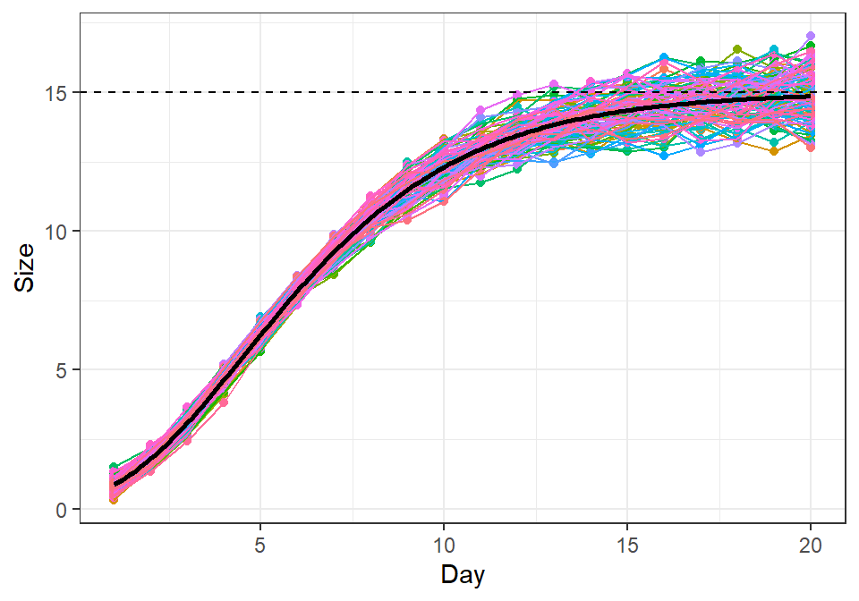

```r
df_mod <- data.frame(
  day = seq(1, 20, by = 0.1)
) |> mutate(
  size = predict(gompertz_model, newdata = data.frame(day = day))
)
dat |> ggplot(aes(x = day, y = size, col = id)) +
  geom_point() +
  geom_line() +
  labs(x = "Day", y = "Size") +
  theme(legend.position="none") +
  geom_hline(yintercept = coef(gompertz_model)["Asym"], linetype = "dashed", color = "black") +
  geom_line(data = df_mod, aes(x = day, y = size),
            inherit.aes = FALSE, color = "black",
            linewidth = 1)
```

Nesplnenie predpokladov mohlo nastať z dôvodov:

- heteroskedasticita náhodných chýb (rozptyl je zjavne vyšší s rastúcim počtom dní);
- chyby nemusia byť nezávislé vrámci jednej jednotky (medzi jednotkami môže byť nezávislosť neporušená).

**Residuals**

Heteroskedasticita reziduí.

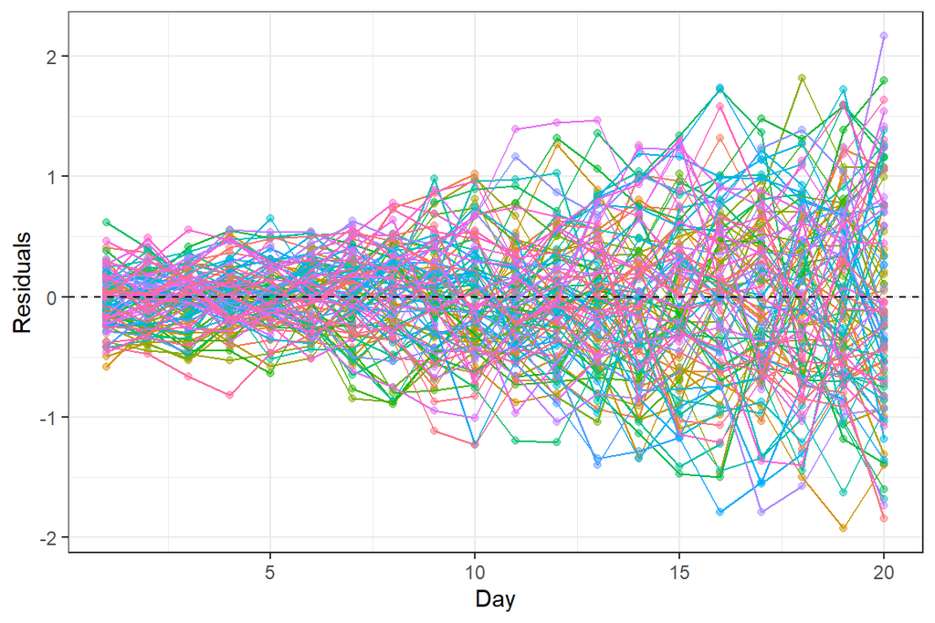

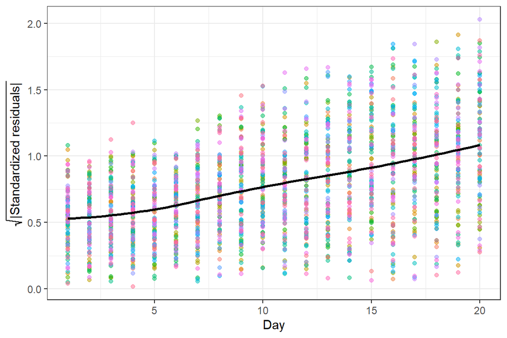

```r
diagnostic_df <- dat
diagnostic_df$resid <- residuals(gompertz_model)
diagnostic_df$fitted <- fitted(gompertz_model)
diagnostic_df$std_resid <- diagnostic_df$resid / sd(diagnostic_df$resid)
diagnostic_df$scale_loc <- sqrt(abs(diagnostic_df$std_resid))

# Residuals vs days
diagnostic_df |> ggplot(aes(x = day, y = resid, color = factor(id))) +
  geom_point(alpha = 0.5) +
  geom_line() +
  geom_hline(yintercept = 0, linetype = "dashed") +
  labs(x = "Day", y = "Residuals") +
  theme(legend.position = "none")
# Scale-Location
diagnostic_df |> ggplot(aes(x = day, y = scale_loc, color = factor(id))) +
  geom_point(alpha = 0.5) +
  geom_smooth(method = "loess", se = FALSE, color = "black") +
  labs(
    x = "Day",
    y = expression(sqrt("|Standardized residuals|"))) +
  theme(legend.position = "none")
```

**ACF & PACF**

Korelácia reziduí $\Rightarrow$ možno $AR(1)$ model.

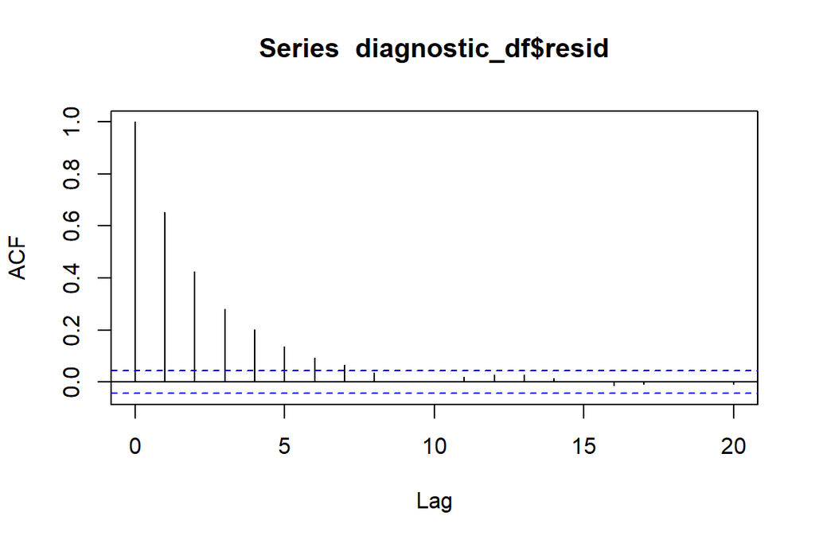

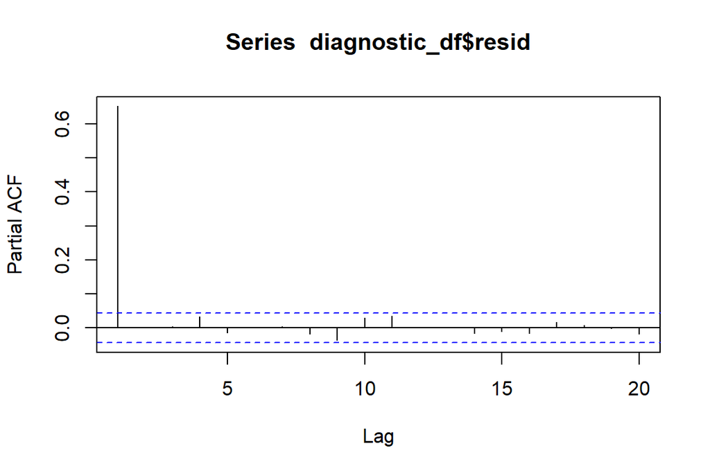

```r
# Acf
acf(diagnostic_df$resid, title = "", lag = 20)
# Pacf
pacf(diagnostic_df$resid, title = "", lag = 20)
```

Reziduá vyzerajú ako $AR(1)$ proces, kde šum nemá konštantný rozptyl, ale zväčšuje sa vzhľadom na čas.

# 2 Konfidenčné intervaly Gompertzovej krivky

**Zadanie**

Data se skládají z opakovaných pozorování na stejných experimentálních jednotkách. Musíme ale vzít v úvahu možnou korelaci pozorování v rámci stejné experimentální jednotky a také heteroskedasticitu. Vzhledem k tomu, že na všech jednotkách byly stejné podmínky, můžeme pracovat s modelem, který má pro všechny jednotky stejné parametry (nemusíme se zabývat jejich heterogenitou, tu je možné modelovat pomocí náhodných efektů, které uvidíme v dalším semestru). Odhadněte směrodatné chyby odhadů parametrů Gompertzova modelu a dále nakreslete graf odhadnuté Gompertzovy křivky spolu s 95% konfidenčními intervaly. Tip: Může se hodit balíček `sandwich`.

## Smerodajné odchýlky parametrov v modeli

Ako som vyberala odhad kovariančnej matice:

- `vcov(gompertz_model)` - naivný prístup
- `vcovHAC(gompertz_model)` - zohľadňuje časovú autokoreláciu, ale nie clustre
- `vcovCL(gompertz_model)` - zohľadňuje clustre, ale nie usporiadanie v clusteroch a časovú autokoreláciu
- `vcovPL(gompertz_model)` - zohľadňuje clustre a aj usporiadanie v clusteroch a časovú autokoreláciu
- `vcovPC(gompertz_model)` - zohľadňuje clustre a cross-sectional koreláciu. Ak som to správne pochopila, nezohľadňuje autokoreláciu vrámci clusteru, ale zohľadňuje koreláciu medzi clustrami

V nasledujúcom kóde používam odhady kovariančnej matice:

- `vcov(gompertz_model)` - naivný prístup
- `vcovCL(gompertz_model, cluster = dat$id)` - clustre a korelácia
- `vcovPL(gompertz_model, cluster = dat$id, order.by = dat$day)` - clustre a časová autokorelácia

Odhad pomocou `vcovPL` sa mi zdá vhodnejší než `vcovCL`, ale metódy na časové rady a panelové dáta sú zvyčajne vhodné na dlhé (časové) dáta, čo 20 dní v tomto prípade nemusí spĺňať. Na druhej strane, reziduá pôsobia ako $AR(1)$ proces s rastúcim rozptylom chýb a myslím si, že na odhad pri jednom lagu môže stačiť aj kratšia časová rada (hlavne keď máme veľa clusterov).

```
CI pre parametre v modeli
```

```r
# Odhady parametrov a kovariancnej matice
params <- c("Asym", "b2", "b3")
estimates <- coef(gompertz_model)
cov_Naive <- vcov(gompertz_model)
cov_CL <- vcovCL(gompertz_model, cluster = dat$id)
cov_PL <- vcovPL(gompertz_model, cluster = dat$id, order.by = dat$day)

# Funkcia na vypocet CI
compute_CI <- function(cov_mat, type) {
  sd_vals <- sqrt(diag(cov_mat))
  data.frame(
    parameter = params,
    estimate = estimates,
    sd = sd_vals,
    method = type,
    lower = estimates - qnorm(0.975) * sd_vals,
    upper = estimates + qnorm(0.975) * sd_vals
  )
}

# CI
CI_naive <- compute_CI(cov_Naive, "vcov")
CI_CL <- compute_CI(cov_CL, "vcovCL")
CI_PL <- compute_CI(cov_PL, "vcovPL")

df_CI_param <- bind_rows(CI_naive, CI_CL, CI_PL) |>
  mutate(parameter = factor(parameter, levels = params)) |>
  arrange(parameter) |>
  select(parameter, method, estimate, sd, lower, upper)
knitr::kable(df_CI_param, digits = 4, row.names = FALSE)
```

| parameter | method | estimate | sd | lower | upper |
| --- | --- | --- | --- | --- | --- |
| Asym | vcov | 15.0159 | 0.0261 | 14.9647 | 15.0670 |
| Asym | vcovCL | 15.0159 | 0.0656 | 14.8874 | 15.1444 |
| Asym | vcovPL | 15.0159 | 0.0150 | 14.9865 | 15.0452 |
| b2 | vcov | 3.8218 | 0.0381 | 3.7470 | 3.8966 |
| b2 | vcovCL | 3.8218 | 0.0341 | 3.7549 | 3.8887 |
| b2 | vcovPL | 3.8218 | 0.0215 | 3.7796 | 3.8640 |
| b3 | vcov | 0.7442 | 0.0015 | 0.7411 | 0.7472 |
| b3 | vcovCL | 0.7442 | 0.0021 | 0.7400 | 0.7484 |
| b3 | vcovPL | 0.7442 | 0.0010 | 0.7423 | 0.7460 |

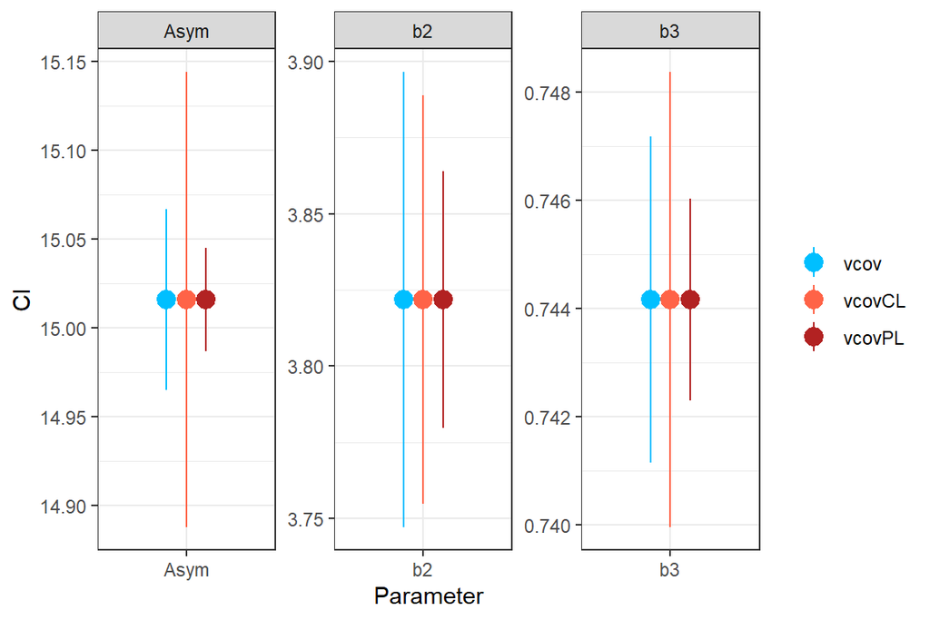

```r
df_CI_param |>
  ggplot(aes(x = parameter, y = estimate, ymin = lower, ymax = upper, color = method)) +
  geom_pointrange(position = position_dodge(width = 0.4), size = 0.8) +
  labs(
    x = "Parameter",
    y = "CI"
  ) +
  scale_color_manual(values = c("vcov" = "deepskyblue", "vcovCL" = "tomato", "vcovPL" = "firebrick")) +
  theme(legend.title = element_blank()) +
  facet_wrap(~parameter, scales = "free")
```

## Konfidenčné intervaly Gompertzovej krivky

Pomocou delta metódy (Taylor) – potrebujeme len gradient a odhadnutú kovariančnú maticu.

```
CI pre krivku
```

```r
# Odhadnuta krivka
day_seq <- seq(0.5, 20.5, len = 101)
model_fit <- predict(gompertz_model, newdata = data.frame(day = day_seq))

# Gradient regresnej krivky
#head(attr(model_fit, "gradient"))

# Funkcia na vypocet:
# Smerodajnej odchylky pre kazdy bod regresnej krivky
# CI regresnej krivky
CI_curve <- function(cov_mat, type) {
  model_fit_se <- double(length(model_fit))
  for (i in 1:length(model_fit_se)) {
    model_fit_se[i] <- sqrt(t(attr(model_fit, "gradient")[i, ]) %*% cov_mat %*% attr(model_fit, "gradient")[i, ])
  }
  data.frame(
    day = day_seq,
    estimate = model_fit,
    sd = model_fit_se,
    method = type,
    lower = model_fit - qnorm(0.975) * model_fit_se,
    upper = model_fit + qnorm(0.975) * model_fit_se
  )
}

# Bodove 95% CI pre krivku
CI_naive <- CI_curve(cov_Naive, "vcov")
CI_CL <- CI_curve(cov_CL, "vcovCL")
CI_PL <- CI_curve(cov_PL, "vcovPL")
```

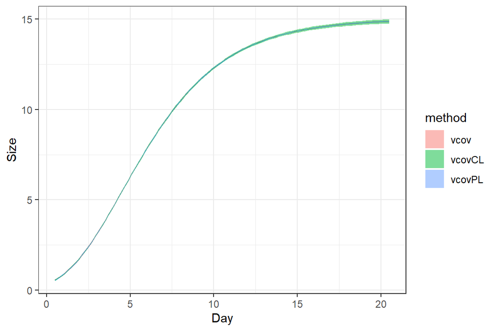

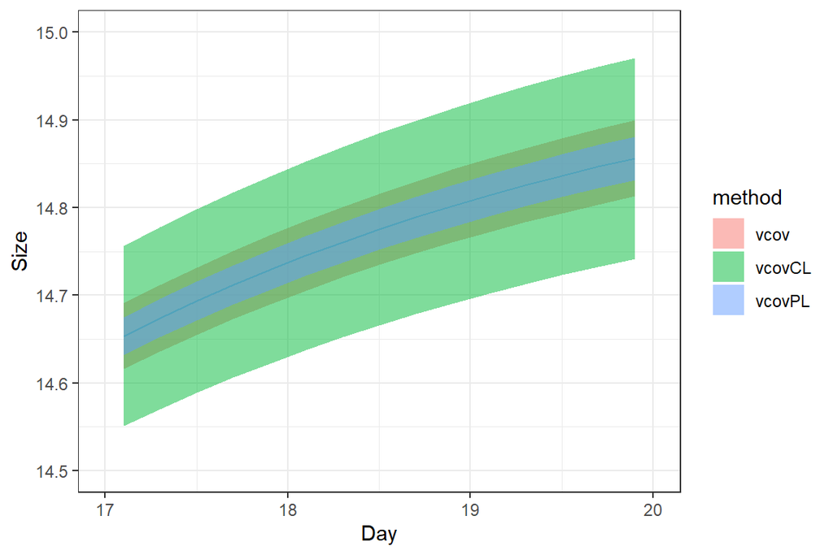

```r
df_CI <- bind_rows(CI_naive, CI_CL, CI_PL)
df_CI |> ggplot(aes(x = day, y = estimate, group = as.factor(method))) +
  geom_line(color = "deepskyblue", linewidth = 0.5) +
  geom_ribbon(aes(ymin = lower, ymax = upper, fill = method), alpha = 0.5) +
  labs(x = "Day", y = "Size")
df_CI |> ggplot(aes(x = day, y = estimate, group = as.factor(method))) +
  geom_line(color = "deepskyblue", linewidth = 0.5) +
  geom_ribbon(aes(ymin = lower, ymax = upper, fill = method), alpha = 0.5) +
  labs(x = "Day", y = "Size") +
  xlim(c(17, 20)) +
  ylim(c(14.5, 15))
```

# 3 Odhad času dosiahnutia hodnoty

**Zadanie**

Odhadněte čas, kdy růstová křivka dosáhne:

- hodnoty 12,
- $80\%$ z limitní hodnoty.

$$\begin{aligned}
y &= Asym \cdot \text{exp}(-b_2 \cdot b_3^x)\\
\frac{y}{Asym} &= \text{exp}(-b_2 \cdot b_3^x)\\
\text{ln}\left( \frac{y}{Asym} \right) &=
-b_2 \cdot b_3^x \\
b_3^x &= -\frac{1}{b_2} \text{ln}\left( \frac{y}{Asym} \right) \\
x &= \text{log}_{b_3} \left[ -\frac{1}{b_2} \text{ln}\left( \frac{y}{Asym} \right) \right] \\
x &= \frac{\text{ln} \left[ -\frac{1}{b_2} \text{ln}\left( \frac{y}{Asym} \right) \right]}{\text{ln}(b_3)}
\end{aligned}$$

```r
Gompertz_inv <- function(y){
  Asym <- coef(gompertz_model)[1]
  b2 <- coef(gompertz_model)[2]
  b3 <- coef(gompertz_model)[3]
  log(-log(y/Asym)/b2)/log(b3)
}

# Dosiahnutie hodnoty
df_val <- data.frame(
  y = c(12, 0.8*coef(gompertz_model)[1])
) |> mutate(
  x = Gompertz_inv(y)
)
knitr::kable(df_val, digits = 4, row.names = FALSE)
```

| y | x |
| --- | --- |
| 12.0000 | 9.5973 |
| 12.0127 | 9.6133 |

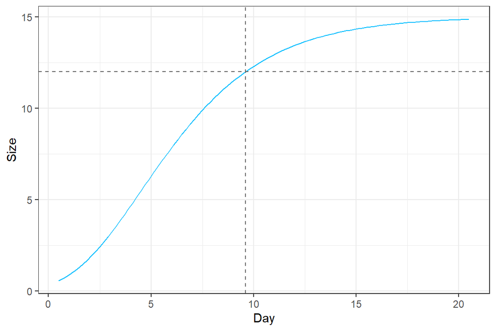

```r
df_CI |> filter(
  method == "vcovPL"
) |> ggplot(aes(x = day, y = estimate)) +
  geom_line(color = "deepskyblue", linewidth = 0.5) +
  labs(x = "Day", y = "Size") +
  geom_hline(data = df_val, aes(yintercept = y), linetype = "dashed", color = "gray40") +
  geom_vline(data = df_val, aes(xintercept = x), linetype = "dashed", color = "gray40")
```

# 4 Konfidenčný interval pre odhad času dosiahnutia hodnoty

**Zadanie**

Najděte 95% konfideční intervaly pro časy dosažení hodnot z předchozího bodu. Tip: Čas dosažení nějaké hodnoty je nelineární funkcí parametrů. Můžete využít některý z následujících postupů nebo nějaký jiný:

- Interval založený na normálním rozdělení s využitím delta metody. Tento způsob vyžaduje analytické vyjádření nebo numerickou aproximaci derivací času dosažení podle jednotlivých parametrů.
- Interval založený na normálním rozdělení s využitím simulace. Myšlenka je generovat mnoho realizací hodnot parametrů z přibližného rozdělení jejich odhadu, pro každou spočítat čas dosažení, z výsledného souboru časů dosažení odhadnout směrodatnou odchylku a použít ji v konstrukci intervalu.
- Některý neparametrický interval založený na simulaci. Myšlenka je generovat soubor časů dosažení jako v předchozím postupu, ale interval konstruovat na základě empirických kvantilů těchto hodnot. Lze použít například takzvaný percentilový interval nebo základní interval, které se často používají v kombinaci s bootstrapem.

Už pracujeme iba s maticou `cov_PL`.

## CI – normálne rozdelenie, delta metóda

Pre pevnú hodnotu $y$:

$$x = \frac{\text{ln} \left[ -\frac{1}{b_2} \text{ln}\left( \frac{y}{Asym} \right) \right]}{\text{ln}(b_3)}$$

$$\begin{aligned}
\frac{\partial x}{\partial Asym} &=
- \frac{1}{Asym \cdot \text{ln}(b_3) \cdot \text{ln}\left( \frac{y}{Asym} \right)} \\
\frac{\partial x}{\partial b_2} &=
- \frac{1}{b_2 \cdot \text{ln}(b_3)} \\
\frac{\partial x}{\partial b_3} &=
- \frac{\text{ln} \left[ -\frac{1}{b_2} \text{ln}\left( \frac{y}{Asym} \right) \right]}{b_3 \cdot \left[ \text{ln}(b_3) \right]^2}
\end{aligned}$$

Pre $y = 0.8 \cdot Asym$ (funkcia parametru):

$$x = \frac{\text{ln} \left[ -\frac{1}{b_2} \text{ln}\left( 0.8 \right) \right]}{\text{ln}(b_3)}$$

$$\begin{aligned}
\frac{\partial x}{\partial Asym} &= 0 \\
\frac{\partial x}{\partial b_2} &=
- \frac{1}{b_2 \cdot \text{ln}(b_3)} \\
\frac{\partial x}{\partial b_3} &=
- \frac{\text{ln} \left[ -\frac{1}{b_2} \text{ln}\left( 0.8 \right) \right]}{b_3 \cdot \left[ \text{ln}(b_3) \right]^2}
\end{aligned}$$

```r
# Funkcia na vyhodnotenie derivacii inverznej Gompertzovej krivky podla parametrov
x_grad <- function(y, asym = FALSE){
  Asym <- coef(gompertz_model)[1]
  b2 <- coef(gompertz_model)[2]
  b3 <- coef(gompertz_model)[3]
  if (asym == FALSE){
    return(-c(1/(Asym * log(y/Asym) * log(b3)),
     1/(b2 * log(b3)),
     log(-log(y/Asym)/b2)/(b3 * log(b3)^2)))
  } else {
    return(-c(0,
     1/(b2 * log(b3)),
     log(-log(y/Asym)/b2)/(b3 * log(b3)^2)))
  }
}

# Funkcia na CI dosiahnutia hodnoty y
CI_norm_delta <- function(y, asym = FALSE){
  day_estimate <- Gompertz_inv(y)
  sd <- sqrt(t(x_grad(y, asym = asym)) %*% cov_PL %*% x_grad(y, asym = asym))
  data.frame(
    method = ifelse(asym == FALSE, "fixed_y", "function_y"),
    size = y,
    day_estimate = day_estimate,
    type = "Norm_Delta",
    lower = day_estimate - qnorm(0.975) * sd,
    upper = day_estimate + qnorm(0.975) * sd
  )
}

df_val_Norm_Delta_12 <- CI_norm_delta(12)
df_val_Norm_Delta_80Asym <- CI_norm_delta(0.8*coef(gompertz_model)[1], asym = TRUE)
df_val_Norm_Delta_80Asym_fix_y <- CI_norm_delta(0.8*coef(gompertz_model)[1])
knitr::kable(rbind(df_val_Norm_Delta_12,
                   df_val_Norm_Delta_80Asym,
                   df_val_Norm_Delta_80Asym_fix_y), digits = 4, row.names = FALSE)
```

| method | size | day_estimate | type | lower | upper |
| --- | --- | --- | --- | --- | --- |
| fixed_y | 12.0000 | 9.5973 | Norm_Delta | 9.5635 | 9.6311 |
| function_y | 12.0127 | 9.6133 | Norm_Delta | 9.5632 | 9.6635 |
| fixed_y | 12.0127 | 9.6133 | Norm_Delta | 9.5795 | 9.6472 |

## CI – normálne rozdelenie, simulácia

```r
library(MASS)

# Funkcia na dosiahnutie hodnoty pomocou inych parametrov
Gompertz_inv_params <- function(y, params){
  Asym <- params[1]
  b2 <- params[2]
  b3 <- params[3]
  log(-log(y/Asym)/b2)/log(b3)
}

# Funkcia na CI dosiahnutia hodnoty y
CI_norm_sim <- function(y, asym = FALSE){
  day_estimate <- Gompertz_inv(y)
  set.seed(1)
  param_sample <- mvrnorm(n = 100,
                          mu = coef(gompertz_model),
                          Sigma = cov_PL)
  if (asym == FALSE){
    day_sample <- sapply(1:nrow(param_sample),
                       \(i){Gompertz_inv_params(y, param_sample[i, ])})
  } else {
    day_sample <- sapply(1:nrow(param_sample),
                         \(i){Gompertz_inv_params(y = 0.8*param_sample[i, 1],
                                                  params = param_sample[i, ])})
  }
  sd <- sd(day_sample)
  data.frame(
    method = ifelse(asym == FALSE, "fixed_y", "function_y"),
    size = y,
    day_estimate = day_estimate,
    type = "Norm_Sim",
    lower = day_estimate - qnorm(0.975) * sd,
    upper = day_estimate + qnorm(0.975) * sd
  )
}

df_val_Norm_Sim_12 <- CI_norm_sim(12)
df_val_Norm_Sim_80Asym <- CI_norm_sim(0.8*coef(gompertz_model)[1], asym = TRUE)
df_val_Norm_Sim_80Asym_fix_y <- CI_norm_sim(0.8*coef(gompertz_model)[1])
knitr::kable(rbind(df_val_Norm_Sim_12,
                   df_val_Norm_Sim_80Asym,
                   df_val_Norm_Sim_80Asym_fix_y), digits = 4, row.names = FALSE)
```

| method | size | day_estimate | type | lower | upper |
| --- | --- | --- | --- | --- | --- |
| fixed_y | 12.0000 | 9.5973 | Norm_Sim | 9.5637 | 9.6310 |
| function_y | 12.0127 | 9.6133 | Norm_Sim | 9.5662 | 9.6604 |
| fixed_y | 12.0127 | 9.6133 | Norm_Sim | 9.5796 | 9.6471 |

## CI – simulácia, percentilový interval

```r
# Funkcia na CI dosiahnutia hodnoty y
CI_sim <- function(y, asym = FALSE){
  day_estimate <- Gompertz_inv(y)
  set.seed(1)
  param_sample <- mvrnorm(n = 100,
                          mu = coef(gompertz_model),
                          Sigma = cov_PL)
  if (asym == FALSE){
    day_sample <- sapply(1:nrow(param_sample),
                       \(i){Gompertz_inv_params(y, param_sample[i, ])})
  } else {
    day_sample <- sapply(1:nrow(param_sample),
                         \(i){Gompertz_inv_params(y = 0.8*param_sample[i, 1],
                                                  params = param_sample[i, ])})
  }
  data.frame(
    method = ifelse(asym == FALSE, "fixed_y", "function_y"),
    size = y,
    day_estimate = day_estimate,
    type = "Sim",
    lower = quantile(day_sample, 0.025),
    upper = quantile(day_sample, 0.975)
  )
}

df_val_Sim_12 <- CI_sim(12)
df_val_Sim_80Asym <- CI_sim(0.8*coef(gompertz_model)[1], asym = TRUE)
df_val_Sim_80Asym_fix_y <- CI_sim(0.8*coef(gompertz_model)[1])
knitr::kable(rbind(df_val_Sim_12,
                   df_val_Sim_80Asym,
                   df_val_Sim_80Asym_fix_y), digits = 4, row.names = FALSE)
```

| method | size | day_estimate | type | lower | upper |
| --- | --- | --- | --- | --- | --- |
| fixed_y | 12.0000 | 9.5973 | Sim | 9.5606 | 9.6309 |
| function_y | 12.0127 | 9.6133 | Sim | 9.5641 | 9.6592 |
| fixed_y | 12.0127 | 9.6133 | Sim | 9.5765 | 9.6470 |

## Porovnanie CI

**12**

```r
df_val_12 <- rbind(df_val_Norm_Delta_12,
                   df_val_Norm_Sim_12,
                   df_val_Sim_12)
knitr::kable(df_val_12, digits = 4, row.names = FALSE)
```

| method | size | day_estimate | type | lower | upper |
| --- | --- | --- | --- | --- | --- |
| fixed_y | 12 | 9.5973 | Norm_Delta | 9.5635 | 9.6311 |
| fixed_y | 12 | 9.5973 | Norm_Sim | 9.5637 | 9.6310 |
| fixed_y | 12 | 9.5973 | Sim | 9.5606 | 9.6309 |

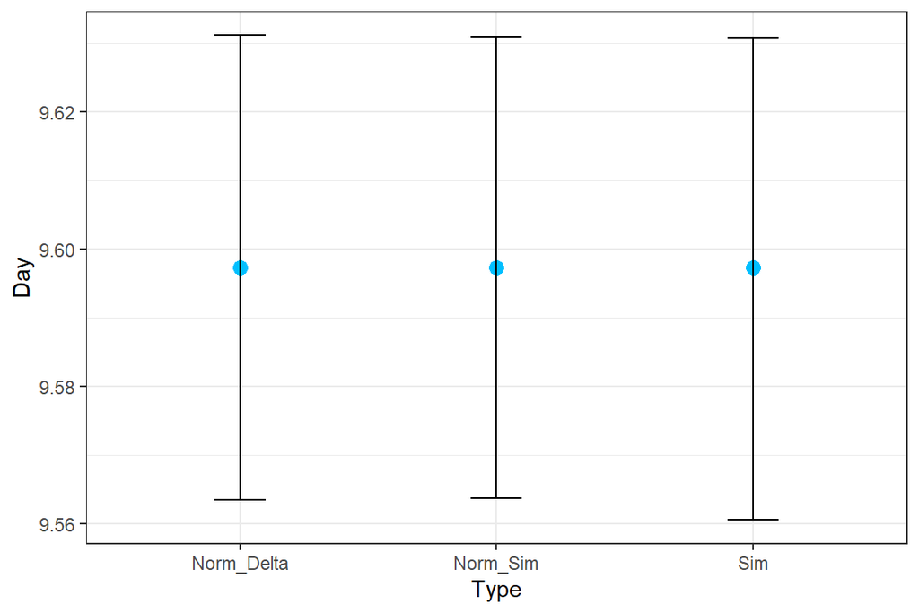

```r
df_val_12 |> ggplot(aes(x = type, y = day_estimate)) +
  geom_point(color = "deepskyblue", size = 3) +
  geom_errorbar(aes(ymin = lower, ymax = upper), width = 0.2, color = "black") +
  labs(x = "Type", y = "Day")
```

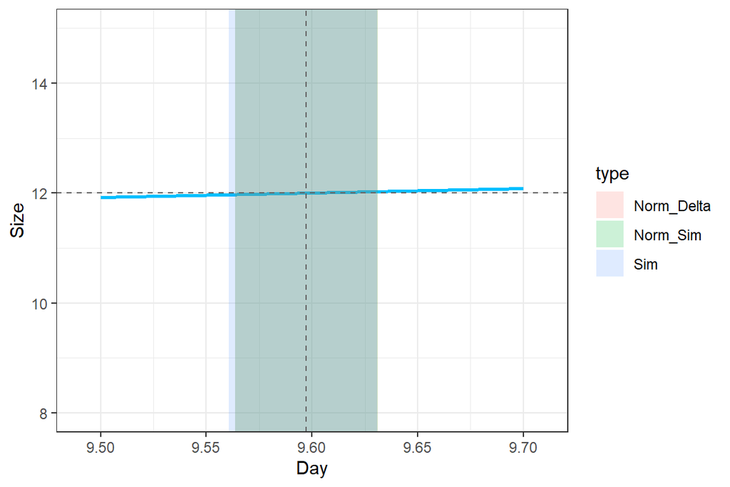

```r
df_mod |>
  ggplot(aes(x = day, y = size)) +
  geom_line(color = "deepskyblue", linewidth = 1) +
  labs(x = "Day", y = "Size") +
  geom_rect(data = df_val_12,
            aes(xmin = lower, xmax = upper, ymin = -Inf, ymax = Inf, fill = type),
            inherit.aes = FALSE,
            alpha = 0.2) +
  geom_hline(data = df_val_12, aes(yintercept = size), linetype = "dashed", color = "gray40") +
  geom_vline(data = df_val_12, aes(xintercept = day_estimate), linetype = "dashed", color = "gray40") +
  xlim(c(9.49, 9.71)) +
  ylim(c(8, 15))
```

**80\%\,Asym**

```r
df_val_80Asym <- rbind(df_val_Norm_Delta_80Asym,
                       df_val_Norm_Delta_80Asym_fix_y,
                       df_val_Norm_Sim_80Asym,
                       df_val_Norm_Sim_80Asym_fix_y,
                       df_val_Sim_80Asym_fix_y,
                       df_val_Sim_80Asym)
knitr::kable(df_val_80Asym, digits = 4, row.names = FALSE)
```

| method | size | day_estimate | type | lower | upper |
| --- | --- | --- | --- | --- | --- |
| function_y | 12.0127 | 9.6133 | Norm_Delta | 9.5632 | 9.6635 |
| fixed_y | 12.0127 | 9.6133 | Norm_Delta | 9.5795 | 9.6472 |
| function_y | 12.0127 | 9.6133 | Norm_Sim | 9.5662 | 9.6604 |
| fixed_y | 12.0127 | 9.6133 | Norm_Sim | 9.5796 | 9.6471 |
| fixed_y | 12.0127 | 9.6133 | Sim | 9.5765 | 9.6470 |
| function_y | 12.0127 | 9.6133 | Sim | 9.5641 | 9.6592 |

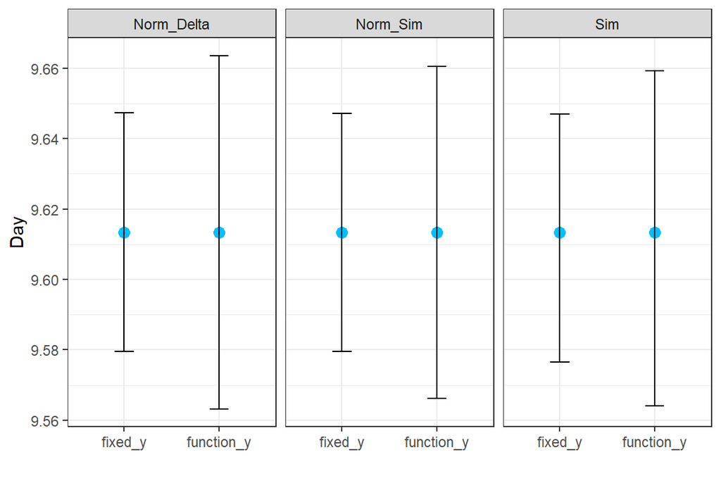

```r
df_val_80Asym |> ggplot(aes(x = method, y = day_estimate)) +
  geom_point(color = "deepskyblue", size = 3) +
  geom_errorbar(aes(ymin = lower, ymax = upper), width = 0.2, color = "black") +
  labs(x = "", y = "Day") +
  facet_wrap(~type)
```

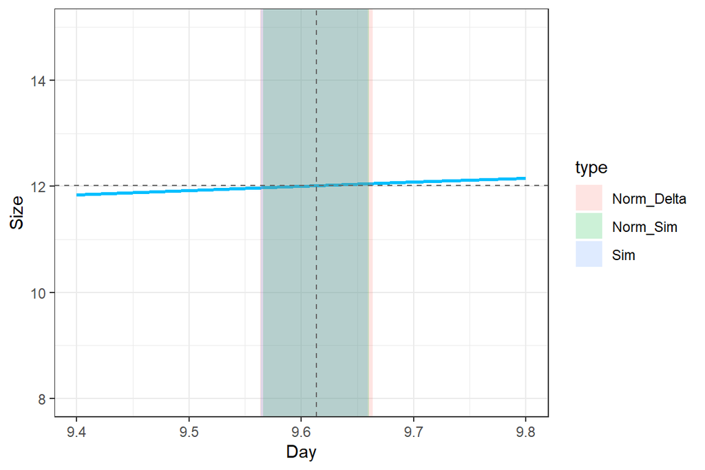

```r
df_val_80Asym <- df_val_80Asym |> filter(
  method == "function_y"
)

df_mod |>
  ggplot(aes(x = day, y = size)) +
  geom_line(color = "deepskyblue", linewidth = 1) +
  labs(x = "Day", y = "Size") +
  geom_rect(data = df_val_80Asym,
            aes(xmin = lower, xmax = upper, ymin = -Inf, ymax = Inf, fill = type),
            inherit.aes = FALSE,
            alpha = 0.2) +
  geom_hline(data = df_val_80Asym, aes(yintercept = size), linetype = "dashed", color = "gray40") +
  geom_vline(data = df_val_80Asym, aes(xintercept = day_estimate), linetype = "dashed", color = "gray40") +
  xlim(c(9.4, 9.8)) +
  ylim(c(8, 15))
```